# BEL Leroux simulation

## Using Debugged codes and moving initial psi from true psi

We run the chain for 50000 iterations and also changed the initial psi to be 0 for each of the small area, following the algorithm in our paper and the Porter paper. The results are shown below. This one is really good in estimating. The only restrictions in place is, we are still assuming the variance to be knowd, taken as the variance of the true psi and we aer using fixed values of rho.

```
## [1] "intercept"
```

```
##    Min. 1st Qu.  Median    Mean 3rd Qu.    Max.
## 0.06198 6.93353 6.95632 6.95614 6.97928 7.08982
```

```
## [1] "slope"
```

```
##     Min.  1st Qu.   Median     Mean  3rd Qu.     Max.
##  0.03858 14.03645 14.06755 14.06765 14.09917 14.27389
```

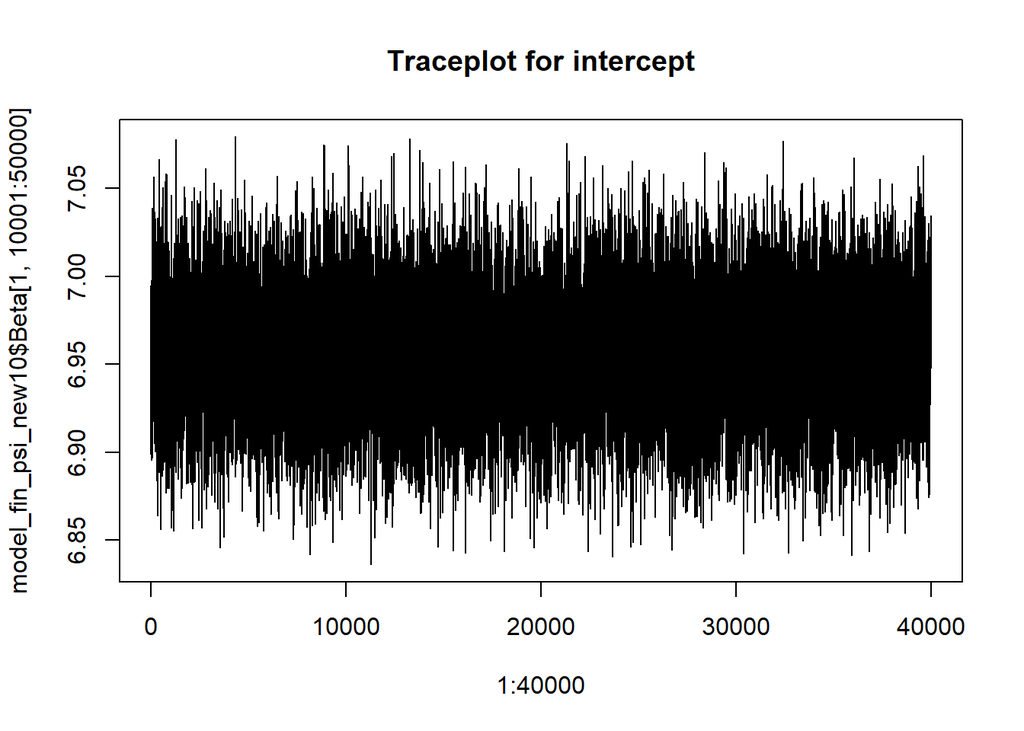

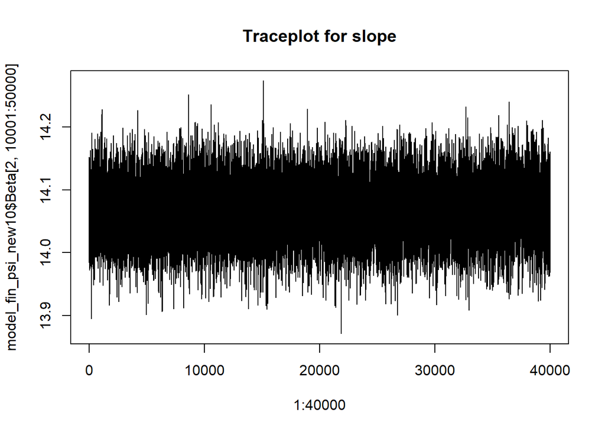

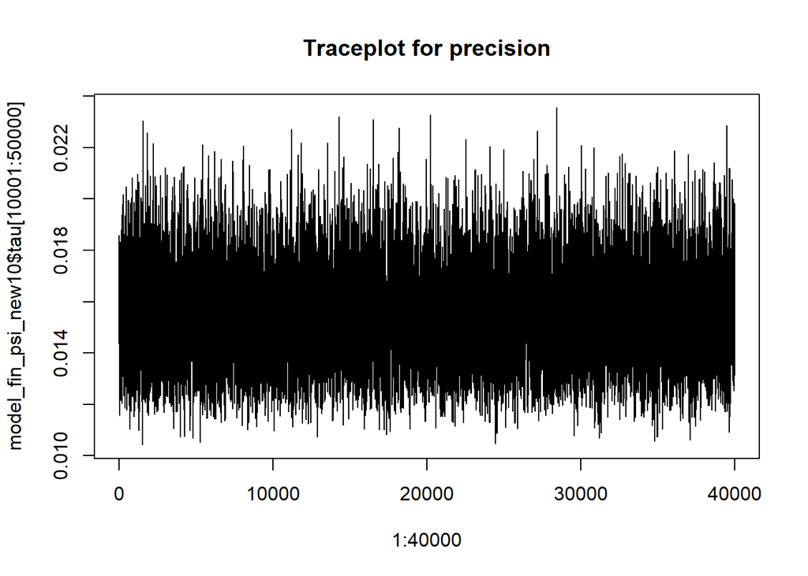

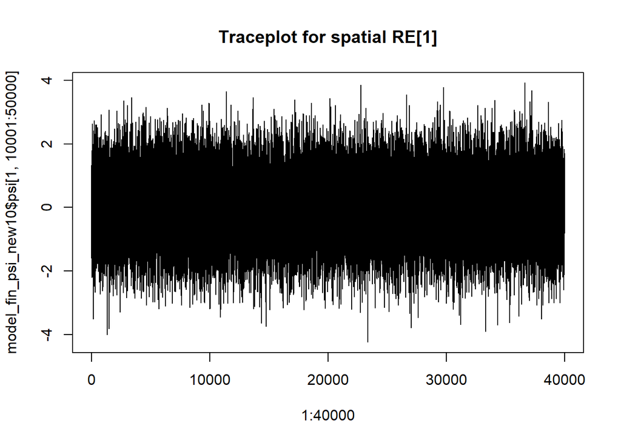

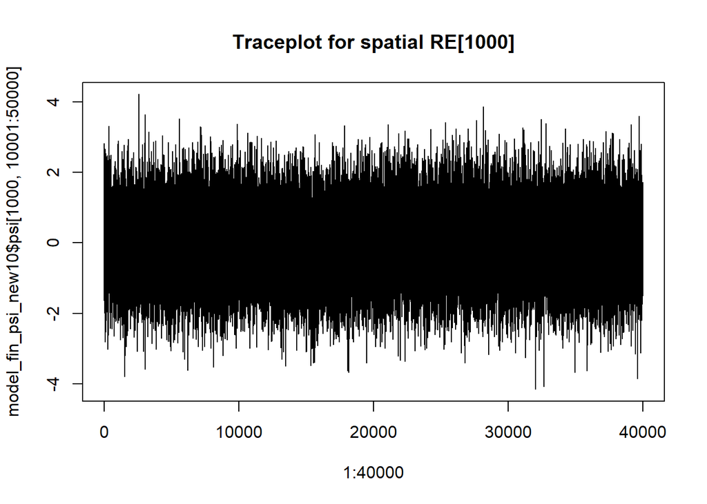

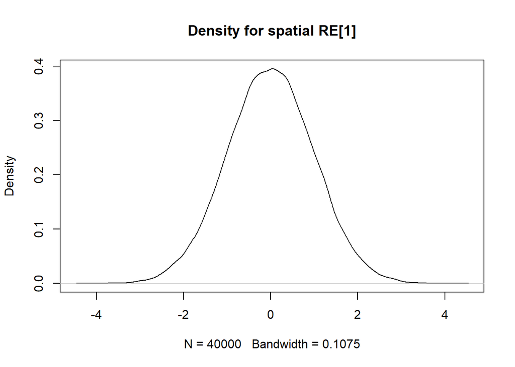

```
## [1] "Precision parameter"
```

```
##    Min. 1st Qu.  Median    Mean 3rd Qu.    Max.
## 0.01042 0.01406 0.01530 0.01648 0.01669 4.50571
```